# Chapter 13. Probability

### 13.1. Discrete probability

```r
beads <- rep(c("red", "blue"), times = c(2,3))
beads
```

```
[1] "red"  "red"  "blue" "blue" "blue"
```

```r
sample(beads,1)
```

```
[1] "blue"
```

This is an example of a *Monte Carlo* simulation. `replicate` function permits us to repeat the same task any number of times.

```r
B <- 10000
events <- replicate(B, sample(beads, 1))
tab <- table(events)
prop.table(tab)
```

```
events
  blue    red
0.6035 0.3965
```

The function `expand.grid` gives all the combinations of entries of two vectors.

```r
suits <- c("Diamonds", "Clubs", "Hearts", "Spades")
numbers <- c("Ace", "Deuce", "Three", "Four", "Five", "Six", "Seven",
             "Eight", "Nine", "Ten", "Jack", "Queen", "King")
deck <- expand.grid(number=numbers, suit=suits)
deck <- paste(deck$number, deck$suit)
```

With the deck constructed, we can double check that the probability of a King in the first card is 1/13 by computing the proportion of possible outcomes that satisfy our condition:

```r
kings <- paste("King", suits)
mean(deck %in% kings)
```

```
[1] 0.07692308
```

We can list out all possible outcomes by using the `permutations` function from the gtools package. For any list of size `n`, this function computes all the different combinations we can get when we select `r` items. Optionally, we can add a vector.

```r
library(gtools)
# compute all possible ways we can choose two cards when the order matters
hands <- permutations(52, 2, v = deck)
first_card <- hands[,1]
second_card <- hands[,2]
kings <- paste("King", suits)
```

```r
# case for which the first hand was a King
sum(first_card %in% kings)

# have a King in the second card
sum(first_card%in%kings & second_card%in%kings) / sum(first_card%in%kings)

# code above is equivalent to :
mean(first_card%in%kings & second_card%in%kings) / mean(first_card%in%kings)
```

```r
aces <- paste("Ace", suits)

facecard <- c("King", "Queen", "Jack", "Ten")
facecard <- expand.grid(number = facecard, suit = suits)
facecard <- paste(facecard$number, facecard$suit)

hands <- combinations(52, 2, v = deck)

mean(hands[,1] %in% aces & hands[,2] %in% facecard)
```

```
[1] 0.04826546
```

```r
mean((hands[,1] %in% aces & hands[,2] %in% facecard) |
       (hands[,2] %in% aces & hands[,1] %in% facecard))
```

```
[1] 0.04826546
```

We draw two cards over and keep track of how many 21s we get. We can use the function `sample` to draw two cards without replacements.

```r
hand <- sample(deck, 2)
hand
```

```
[1] "Queen Spades" "Five Spades"
```

Check if one card is an Ace and the other a face card or a 10. Going forward, we include 10 when we say face card. Now we need to check both possibilities:

```r
(hands[1] %in% aces & hands[2] %in% facecard) |
  (hands[2] %in% aces & hands[1] %in% facecard)
```

```
[1] FALSE
```

If we repeat this 10,000 times, we get a very good approximation of the probability of a Natural 21.

```r
blackjack <- function(){
   hand <- sample(deck, 2)
  (hand[1] %in% aces & hand[2] %in% facecard) |
    (hand[2] %in% aces & hand[1] %in% facecard)
}
blackjack()
```

```
[1] FALSE
```

```r
B <- 10000
results <- replicate(B, blackjack())
mean(results)
```

```
[1] 0.0452
```

### Monty Hall problem

```r
B <- 10000

monty_hall <- function(strategy){
  doors <- as.character(1:3)
  prize <- sample(c("car", "goat", "goat"))
  prize_door <- doors[prize == "car"]
  my_pick  <- sample(doors, 1)
  show <- sample(doors[!doors %in% c(my_pick, prize_door)],1)
  stick <- my_pick
  stick == prize_door
  switch <- doors[!doors%in%c(my_pick, show)]
  choice <- ifelse(strategy == "stick", stick, switch)
  choice == prize_door
}

stick <- replicate(B, monty_hall("stick"))
mean(stick)
```

```
[1] 0.3351
```

```r
switch <- replicate(B, monty_hall("switch"))
mean(switch)
```

```
[1] 0.663
```

### Birthday problem

```r
n <- 50
bdays <- sample(1:365, n, replace = TRUE)

B <- 10000
same_birthday <- function(n){
  bdays <- sample(1:365, n, replace=TRUE)
  any(duplicated(bdays))
}
results <- replicate(B, same_birthday(50))
mean(results)
```

```
[1] 0.9687
```

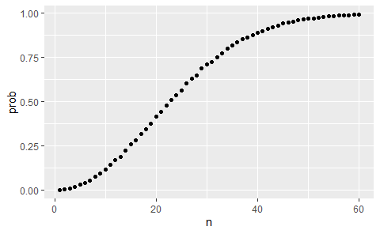

```r
compute_prob <- function(n, B=10000){
  results <- replicate(B, same_birthday(n))
  mean(results)
}

n <- seq(1,60)
prob <- sapply(n, compute_prob)

library(tidyverse)
prob <- sapply(n, compute_prob)
qplot(n, prob)
```

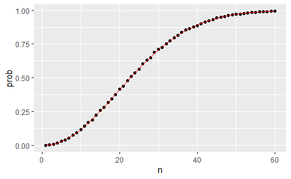

```r
exact_prob <- function(n){
  prob_unique <- seq(365,365-n+1)/365
  1 - prod( prob_unique)
}
eprob <- sapply(n, exact_prob)
qplot(n, prob) + geom_line(aes(n, eprob), col = "red")
```

### Infinity in practice

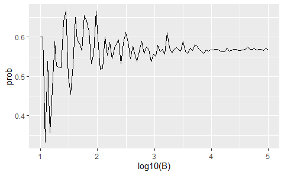

```r
B <- 10^seq(1, 5, len = 100)
compute_prob <- function(B, n=25){
  same_day <- replicate(B, same_birthday(n))
  mean(same_day)
}
prob <- sapply(B, compute_prob)
qplot(log10(B), prob, geom = "line")
```

### Exercises

1. One ball will be drawn at random from a box containing: 3 cyan balls, 5 magenta balls, and 7 yellow balls. What is the probability that the ball will be cyan?

Answer : 3/15

2. What is the probability that the ball will not be cyan?

Answer : 12/15

3. Instead of taking just one draw, consider taking two draws. You take the second draw without returning the first draw to the box. We call this sampling without replacement. What is the probability that the first draw is cyan and that the second draw is not cyan?

Answer : 3/15 x 12/14

4. Now repeat the experiment, but this time, after taking the first draw and recording the color, return it to the box and shake the box. We call this sampling with replacement. What is the probability that the first draw is cyan and that the second draw is not cyan?

Answer : 3/15 x 12/15

5. Two events $A$ and $B$ are independent if $Pr(A and B)=Pr(A)P(B)$. Under which situation are the draws independent?

Answer : b

6. Say you’ve drawn 5 balls from the box, with replacement, and all have been yellow. What is the probability that the next one is yellow?

Answer : 7/15

7. If you roll a 6-sided die six times, what is the probability of not seeing a 6?

Answer : (5/6)^6

8. Two teams, say the Celtics and the Cavs, are playing a seven game series. The Cavs are a better team and have a 60% chance of winning each game. What is the probability that the Celtics win at least one game?

Answer : 1 - (60/100)^7

9. Create a Monte Carlo simulation to confirm your answer to the previous problem. Use `B <- 10000` simulations. Hint: use the following code to generate the results of the first four games:

Answer :

```r
B <- 10000
celtic_wins <- sample(c(0,1), 4, replace = TRUE, prob = c(0.6, 0.4))

results <- replicate(B, sample(celtic_wins, 1))
mean(results)
```

```
[1] 0.5088
```

10. Two teams, say the Cavs and the Warriors, are playing a seven game championship series. The first to win four games, therefore, wins the series. The teams are equally good so they each have a 50-50 chance of winning each game. If the Cavs lose the first game, what is the probability that they win the series?

Answer : 11/32

11. Confirm the results of the previous question with a Monte Carlo simulation.

```r
B <- 10000
cavs_wins <- function(){
  cavs_wins <- sample(c(0,1), 7, replace = TRUE, prob = c(0.5, 0.5))
  any(cavs_wins %in% "1")
}
```

[output not shown]

12. Two teams, A and B are playing a seven game series. Team A is better than team B and has a p > 0.5 chance of winning each game. Given a value p, the probability of winning the series for the underdog team B can be computed with the following function based on a Monte Carlo simulation:

```r
prob_win <- function(p){
  B <- 10000
  result <- replicate(B, {
    b_win <- sample(c(1,0), 7, replace = TRUE, prob = c(1-p, p))
    sum(b_win)>=4
  })
  mean(result)
}
```

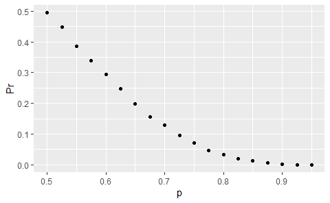

```r
prob_win <- function(p){
  B <- 10000
  result <- replicate(B, {
    b_win <- sample(c(1,0), 7, replace = TRUE, prob = c(1-p, p))
    sum(b_win)>=4
  })
  mean(result)
}

p <- seq(0.5, 0.95, 0.025)
Pr <- sapply(p, prob_win)
qplot(p, Pr)
```

13. Repeat the exercise above, but now keep the probability fixed at `p <- 0.75` and compute the probability for different series lengths : N <- seq(1, 25, 2).

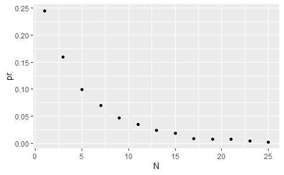

```r
prob_win <- function(N, p=0.75){
  B <- 10000
  result <- replicate(B, {
    b_win <- sample(c(1,0), N, replace = TRUE, prob = c(1-p, p))
    sum(b_win)>=(N+1)/2
  })
  mean(result)
}

N <- seq(1, 25, 2)
pr <- sapply(N, prob_win)
qplot(N, pr)
```